# PCA Churn Prediction- Bank data

## PCA Churn Prediction - Bank Data

**Importing the Required Liabraries & Packages**

```python
import numpy as np
import pandas as pd
import matplotlib.pyplot as plt
import os
from sklearn.decomposition import PCA
import seaborn as sns
%matplotlib inline
from matplotlib.pylab import rcParams
rcParams['figure.figsize']=15,10
from sklearn.preprocessing import StandardScaler
from sklearn.model_selection import train_test_split
from sklearn.linear_model import LogisticRegression
from sklearn.metrics import accuracy_score,confusion_matrix,classification_report
from sklearn.ensemble import RandomForestClassifier
from sklearn.tree import DecisionTreeClassifier
import pickle
import warnings
warnings.filterwarnings('ignore')
```

**Changing the default working directory path&Reading the Dataset using Pandas Command**

```python
os.chdir('C:\\Users\\mural\\Documents\\Batch 74 Day 19')
df=pd.read_csv('Bank Data Dimension Reduction.csv')
```

## Data Cleaning:

**checking the null values in the all columns of the dataset**

```python
df.isna().sum()
```

```
Index        0
Interest    68
Credit       0
Gender      21
Previous     7
Duration    70
Churn        0
dtype: int64
```

**Dropping the columns which is not needed for model fitting**

```python
df.drop(['Index'],axis=1,inplace=True)
```

**Grouping by the Gender column to find out the maximum repeated values**

```python
df.groupby('Gender').size()
```

```
Gender
0.0    290
1.0    289
dtype: int64
```

**Filling the null values of Gender column with most frequent value**

```python
df['Gender']=df['Gender'].fillna(0)
```

**Grouping by the Gender column to find out the maximum repeated values after updating**

```python
df.groupby('Gender').size()
```

```
Gender
0.0    311
1.0    289
dtype: int64
```

**Getting the Unique Value and its counts in the Previous Column from the Dataset**

```python
df['Previous'].value_counts()
```

```
0.0    302
1.0    291
Name: Previous, dtype: int64
```

**Filling the null values of Previous column with most frequent value and Getting the Unique Value and its counts in the Column from the Dataset after updating**

```python
df['Previous']=df['Previous'].fillna(0)
df['Previous'].value_counts()
```

```
0.0    309
1.0    291
Name: Previous, dtype: int64
```

**Filling the null values of Interest column with mean values**

```python
df['Interest'].fillna(df['Interest'].mean(),inplace=True)
```

**Filling the null values of Duration column with median values**

```python
df['Duration'].fillna(df['Duration'].median(),inplace=True)
```

**checking the null values in the all columns of the dataset after updating**

```python
df.isna().sum()
```

```
Interest    0
Credit      0
Gender      0
Previous    0
Duration    0
Churn       0
dtype: int64
```

**checking out the data type of all the columns in the dataset so that it can be converted to appropriate data type for the model fitting**

```python
df.dtypes
```

```
Interest    float64
Credit        int64
Gender      float64
Previous    float64
Duration    float64
Churn        object
dtype: object
```

**Lable encoding both the Gender and Previous Column from the Dataset**

```python
df['Gender']=df['Gender'].astype('category')
df['Previous']=df['Previous'].astype('category')
```

**Lable encoding both the Churn Column from the Dataset**

```python
df['Churn']=df['Churn'].astype('category')
df['Churn']=df['Churn'].cat.codes
```

**"Assigning the dependent and independent Variable"**

```python
x=df.iloc[:,:-1]
y=df.iloc[:,-1]
```

## Data Cleaning:

**Standardizing the independent variable of the dataset**

```python
sc=StandardScaler()
x=sc.fit_transform(x)
```

**Processing the independent variable with principal component analysis to get the importance of all the columns in the independent variable**

```python
pca=PCA()
df1=pca.fit_transform(x)
```

**Getting the numeric value form the columns of the independent variable variable**

```python
pca.explained_variance_ratio_
```

```
array([0.33943997, 0.20168854, 0.20083191, 0.18998087, 0.06805872])
```

**Splitting the dependent and independent variable into training and test dataset using train test split**

```python
x_train,x_test,y_train,y_test=train_test_split(x,y,test_size=0.2,random_state=33)
```

**Fitting the Logistic Regressor Model with the train dependent and train independent variable and getting Accuracy score between the predicted values and dependent test dataset**

```python
lr=LogisticRegression()
lr.fit(x_train,y_train)
lr_pred=lr.predict(x_test)
print('\n Accuracy score:',accuracy_score(y_test,lr_pred),'\n')
print('\n Confusion matrix:\n',confusion_matrix(y_test,lr_pred),'\n')
print('\n Classification report:\n',classification_report(y_test,lr_pred),'\n')
```

```
 Accuracy score: 0.7666666666666667


 Confusion matrix:
 [[ 0 28]
 [ 0 92]]


 Classification report:
               precision    recall  f1-score   support

           0       0.00      0.00      0.00        28
           1       0.77      1.00      0.87        92

    accuracy                           0.77       120
   macro avg       0.38      0.50      0.43       120
weighted avg       0.59      0.77      0.67       120
```

**Fitting the DecisionTree Classifier Model with the train dependent and train independent variable and getting Accuracy score between the predicted values and dependent test dataset**

```python
DT=DecisionTreeClassifier(random_state=99)
DT.fit(x_train,y_train)
DT_pred=DT.predict(x_test)
print('\n Accuracy score:',accuracy_score(y_test,DT_pred),'\n')
print('\n Confusion matrix:\n',confusion_matrix(y_test,DT_pred),'\n')
print('\n Classification report:\n',classification_report(y_test,DT_pred),'\n')
```

```
 Accuracy score: 0.675


 Confusion matrix:
 [[ 8 20]
 [19 73]]


 Classification report:
               precision    recall  f1-score   support

           0       0.30      0.29      0.29        28
           1       0.78      0.79      0.79        92

    accuracy                           0.68       120
   macro avg       0.54      0.54      0.54       120
weighted avg       0.67      0.68      0.67       120
```

**Fitting the Random Forest Classifier Model with the train dependent and train independent variable and getting Accuracy score between the predicted values and dependent test dataset**

```python
RF=RandomForestClassifier(random_state=99)
RF.fit(x_train,y_train)
RF_pred=RF.predict(x_test)
print('\n Accuracy score:',accuracy_score(y_test,RF_pred),'\n')
print('\n Confusion matrix:\n',confusion_matrix(y_test,RF_pred),'\n')
print('\n Classification report:\n',classification_report(y_test,RF_pred),'\n')
```

```
 Accuracy score: 0.6666666666666666


 Confusion matrix:
 [[ 1 27]
 [13 79]]


 Classification report:
               precision    recall  f1-score   support

           0       0.07      0.04      0.05        28
           1       0.75      0.86      0.80        92

    accuracy                           0.67       120
   macro avg       0.41      0.45      0.42       120
weighted avg       0.59      0.67      0.62       120
```

## Dimensional Reduction:

**Processing the independent variable with principal analysis of 2 components to get the importance of all the columns in the independent variable**

```python
pca1=PCA(n_components=2)
pca_x=pca1.fit_transform(x)
```

**Getting the numeric value form the columns of the independent variable after reducing the dimensional**

```python
pca1.explained_variance_ratio_
```

```
array([0.33943997, 0.20168854])
```

**Splitting the dependent and independent variable into training and test dataset using train test split after reducing the dimensional**

```python
pca_x_train,pca_x_test,y_train,y_test=train_test_split(pca_x,y,test_size=0.2,random_state=33)
```

**Fitting the Logistic Regressor Model with the train dependent and train independent variable and getting Accuracy score between the predicted values and dependent test dataset after reducing the dimensional**

```python
LR1=LogisticRegression()
LR1.fit(pca_x_train,y_train)
LR1_pred=LR1.predict(pca_x_test)
print('\n Accuracy score:',accuracy_score(y_test,LR1_pred),'\n')
print('\n Confusion matrix:\n',confusion_matrix(y_test,LR1_pred),'\n')
print('\n Classification report:\n',classification_report(y_test,LR1_pred),'\n')
```

```
 Accuracy score: 0.7666666666666667


 Confusion matrix:
 [[ 0 28]
 [ 0 92]]


 Classification report:
               precision    recall  f1-score   support

           0       0.00      0.00      0.00        28
           1       0.77      1.00      0.87        92

    accuracy                           0.77       120
   macro avg       0.38      0.50      0.43       120
weighted avg       0.59      0.77      0.67       120
```

**Fitting the DecisionTree Classifier Model with the train dependent and train independent variable and getting Accuracy score between the predicted values and dependent test dataset after reducing the dimensional**

```python
DT1=DecisionTreeClassifier(random_state=99)
DT1.fit(pca_x_train,y_train)
DT1_pred=DT1.predict(pca_x_test)
print('\n Accuracy score:',accuracy_score(y_test,DT1_pred),'\n')
print('\n Confusion matrix:\n',confusion_matrix(y_test,DT1_pred),'\n')
print('\n Classification report:\n',classification_report(y_test,DT1_pred),'\n')
```

```
 Accuracy score: 0.625


 Confusion matrix:
 [[ 9 19]
 [26 66]]


 Classification report:
               precision    recall  f1-score   support

           0       0.26      0.32      0.29        28
           1       0.78      0.72      0.75        92

    accuracy                           0.62       120
   macro avg       0.52      0.52      0.52       120
weighted avg       0.66      0.62      0.64       120
```

**Fitting the Random Forest Classifier Model with the train dependent and train independent variable and getting Accuracy score between the predicted values and dependent test dataset after reducing the dimensional**

```python
RF1=RandomForestClassifier(random_state=99)
RF1.fit(pca_x_train,y_train)
RF1_pred=RF1.predict(pca_x_test)
print('\n Accuracy score:',accuracy_score(y_test,RF1_pred),'\n')
print('\n Confusion matrix:\n',confusion_matrix(y_test,RF1_pred),'\n')
print('\n Classification report:\n',classification_report(y_test,RF1_pred),'\n')
```

```
 Accuracy score: 0.6833333333333333


 Confusion matrix:
 [[ 6 22]
 [16 76]]


 Classification report:
               precision    recall  f1-score   support

           0       0.27      0.21      0.24        28
           1       0.78      0.83      0.80        92

    accuracy                           0.68       120
   macro avg       0.52      0.52      0.52       120
weighted avg       0.66      0.68      0.67       120
```

**Processing the independent variable with principal analysis of 4 components to get the importance of all the columns in the independent variable**

```python
pca2=PCA(n_components=4)
pca_x2=pca2.fit_transform(x)
```

**Getting the numeric value form the columns of the independent variable after reducing the dimensional**

```python
pca2.explained_variance_ratio_
```

```
array([0.33943997, 0.20168854, 0.20083191, 0.18998087])
```

**Splitting the dependent and independent variable into training and test dataset using train test split after reducing the dimensional**

```python
pca_x_train,pca_x_test,y_train,y_test=train_test_split(pca_x2,y,test_size=0.2,random_state=33)
```

**Fitting the Logistic Regressor Model with the train dependent and train independent variable and getting Accuracy score between the predicted values and dependent test dataset after reducing the dimensional**

```python
LR2=LogisticRegression()
LR2.fit(pca_x_train,y_train)
LR2_pred=LR2.predict(pca_x_test)
print('\n Accuracy score:',accuracy_score(y_test,LR2_pred),'\n')
print('\n Confusion matrix:\n',confusion_matrix(y_test,LR2_pred),'\n')
print('\n Classification report:\n',classification_report(y_test,LR2_pred),'\n')
```

```
 Accuracy score: 0.7666666666666667


 Confusion matrix:
 [[ 0 28]
 [ 0 92]]


 Classification report:
               precision    recall  f1-score   support

           0       0.00      0.00      0.00        28
           1       0.77      1.00      0.87        92

    accuracy                           0.77       120
   macro avg       0.38      0.50      0.43       120
weighted avg       0.59      0.77      0.67       120
```

**Fitting the DecisionTree Classifier Model with the train dependent and train independent variable and getting Accuracy score between the predicted values and dependent test dataset after reducing the dimensional**

```python
DT2=DecisionTreeClassifier(random_state=99)
DT2.fit(pca_x_train,y_train)
DT2_pred=DT2.predict(pca_x_test)
print('\n Accuracy score:',accuracy_score(y_test,DT2_pred),'\n')
print('\n Confusion matrix:\n',confusion_matrix(y_test,DT2_pred),'\n')
print('\n Classification report:\n',classification_report(y_test,DT2_pred),'\n')
```

```
 Accuracy score: 0.5666666666666667


 Confusion matrix:
 [[ 2 26]
 [26 66]]


 Classification report:
               precision    recall  f1-score   support

           0       0.07      0.07      0.07        28
           1       0.72      0.72      0.72        92

    accuracy                           0.57       120
   macro avg       0.39      0.39      0.39       120
weighted avg       0.57      0.57      0.57       120
```

**Fitting the Random Forest Classifier Model with the train dependent and train independent variable and getting Accuracy score between the predicted values and dependent test dataset after reducing the dimensional**

```python
RF2=RandomForestClassifier(random_state=99)
RF2.fit(pca_x_train,y_train)
RF2_pred=RF2.predict(pca_x_test)
print('\n Accuracy score:',accuracy_score(y_test,RF2_pred),'\n')
print('\n Confusion matrix:\n',confusion_matrix(y_test,RF2_pred),'\n')
print('\n Classification report:\n',classification_report(y_test,RF2_pred),'\n')
```

```
 Accuracy score: 0.6583333333333333


 Confusion matrix:
 [[ 3 25]
 [16 76]]


 Classification report:
               precision    recall  f1-score   support

           0       0.16      0.11      0.13        28
           1       0.75      0.83      0.79        92

    accuracy                           0.66       120
   macro avg       0.46      0.47      0.46       120
weighted avg       0.61      0.66      0.63       120
```

**Create the pickle file on the model with the highest Accuracy score with the model name**

```python
pickle.dump(lr,open('PCA pickle.pkl','wb'))
```

**Loading the pickle file**

```python
model=pickle.load(open('PCA pickle.pkl','rb'))
```

**Predicted the Whole data using the loaded pickle file**

```python
y_fpred=model.predict(x)
print('\n Accuracy score:\n',accuracy_score(y,y_fpred),'\n')
print('\n Confusion matrix:\n',confusion_matrix(y,y_fpred),'\n')
print('\n Classification report:\n',classification_report(y,y_fpred),'\n')
```

```
 Accuracy score:
 0.7583333333333333


 Confusion matrix:
 [[  0 145]
 [  0 455]]


 Classification report:
               precision    recall  f1-score   support

           0       0.00      0.00      0.00       145
           1       0.76      1.00      0.86       455

    accuracy                           0.76       600
   macro avg       0.38      0.50      0.43       600
weighted avg       0.58      0.76      0.65       600
```

**Spotting the Graph with Accuracy of Predicted value and Actual Value and saving the PNG file**

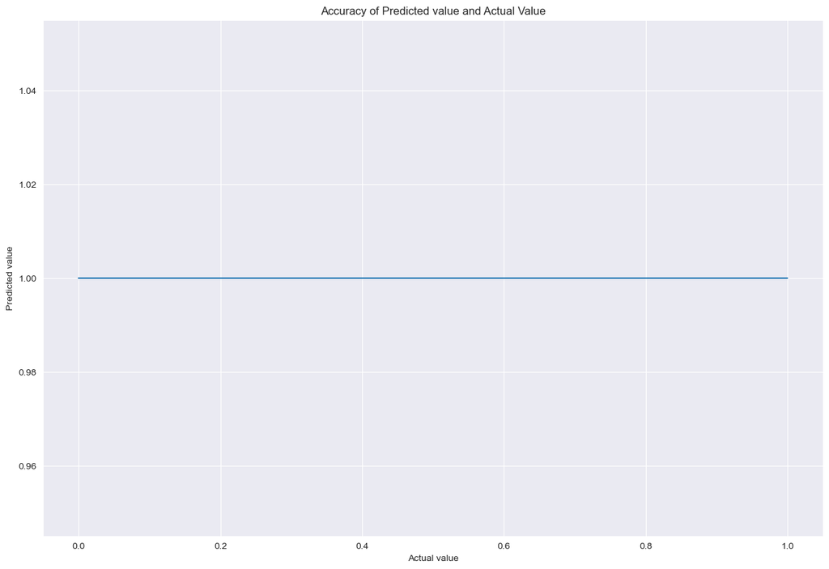

```python
sns.set_style('darkgrid')
plt.plot(y,y_fpred)
plt.xlabel('Actual value')
plt.ylabel('Predicted value')
plt.title('Accuracy of Predicted value and Actual Value')
plt.savefig('Accuracy of Predicted value and Actual Value.png')
plt.show()
```